# Code for Exploring Objective Functions

Daniel Klotz

13 Juli 2016

# 1 Introduction

This section defines the code of a [shiny app](http://shiny.rstudio.com/) that lets users explore the (hydro-) graphs for the different basins in conjunction with objective functions for the user-selected time-window. The calculation of the objective functions are independent of the code defined in the section about `calculating_of`, since simpler constructions are preferable in the case at hand and more information is given to the user.

The computations of the app are defined in the `server` part and the appearance in the `ui`.

# 2 Example

```r
viscos_options(color_data1 = "green", color_data2 = "red")
explore_runoff_with_of(runoff_example)
```

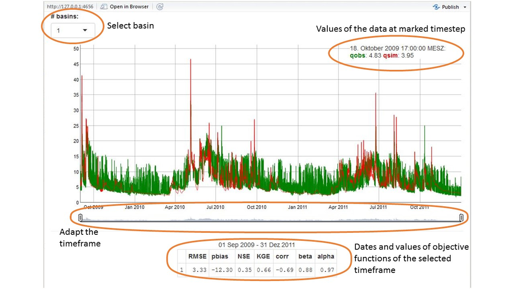

Users can select different basins via the selection box (*# basins:*) on the top-left and interactively zoom and move the graph in the center by clicking on it or moving the date switches below the graph. While doing so the objective functions (presented in the table below) are re-calculated for the chosen time window.

# 3 Code

In the following paragraphs the code of the shiny app is defined.

This function represents the main part of the shiny app.

```r
  #' explore runoff_data with Objective Functions
  #'
  #' Runs a Shiny App which can be used to get an overview of a runoff_data time
  #' series object.
  #'
  #' @param d_xts runoff_data formatted as time series
  #'
  #' @import shiny
  #' @importFrom xts xts
  #' @import dplyr
  #' @import magrittr
  #' @import dygraphs
  #' @import hydroGOF
  #'
  #' @export
  #'
  #' @examples
  #' # get example data,
  #' # clean it and
  #' # explore the model performance
  #' d_runoff <- get_runoff_example()
  #' explore_runoff_with_of(d_runoff)
explore_runoff_with_of <- function(runoff_data) {
```

At its current state the shiny app needs some pre-calculation, which are defined in this part of the code:

- 1. Defensive code (basically, the leadign zeros are removed from colum names and the date formated is completed and ).
- 2. Transform data into `xts` (`d_xts`).
- 3. Save numeration of basins within the variable `d_nums`.

**Note** that this approach forces users to enumerate their basins with integers. `Doubles` would be transformed into integers by the `as.integer` command!

```r
  # pre-calculations
  # (I)
  clean_runoff_data <- runoff_data %>% remove_leading_zeros
  if ( !viscos_options("name_COSposix") %in% names(clean_runoff_data) ) {
    clean_runoff_data %<>% prepare_complete_date
  }
  # (II)
  d_xts <- runoff_as_xts(clean_runoff_data)
  # (III)
  idx_names <- names(d_xts) %>%
    tolower %>%
    grepl(viscos_options("name_data1"),.)
  d_nums <- d_xts %>%
      names() %>%
      .[idx_names] %>%
      gsub("\\D","",.) %>%
      as.integer %>%
      unique
```

The server-side of the shiny app is rather lengthy but not too difficult. The major readability problems occur because of the unusual formatting enforced by shiny. The `reactive({})` marks all the interactive parts of the server. The calculations are saved in the output-structures, which is handed over to the `ui`. The graphs are saved/plotted to `output$hydrographs` and the objective functions to `output$slctd_OF`. The start and end of the current time window is handed as string to the variable `output$selected_timewindow`. This requires some transformation from the obtained `xts` values. This is done with `strftime(., format = "%d %b %Y)`, which converts between character representations and objects of `POSIXlt` and `POSIXct`.

```r
  server <- function(input, output, session) {
    # (I) get strings used in the naming of clean_runoff_data:
    unique_data_names <- names(clean_runoff_data) %>%
      gsub("\\d","",.) %>%
      tolower %>%
      unique
    x_string <- unique_data_names[ unique_data_names %>%
                                     grep(viscos_options("name_data1"),.) ]
    y_string <- unique_data_names[ unique_data_names  %>%
                                     grep(viscos_options("name_data2"),.) ]
    # (II) select data:
    '%&%' <- function(a,b) paste(a,b,sep = "") # %&% as substitute for function
    selector_x <- reactive({ x_string %&% input$basin_num %&% "$" }) # "$" terminates the searchstring; see regex
    selector_y <- reactive({ y_string %&% input$basin_num %&% "$" })
    selected_data <- reactive({
      select(clean_runoff_data,
             matches( selector_x() ),
             matches( selector_y() )
             ) %>%
        select(x = matches( selector_x() ),
               y = matches( selector_y() ))
    })
    # (III) create xts-formated table for use in dygraphs:
    xts_selected_data <- reactive ({
      xts(selected_data(),
          order.by = clean_runoff_data[[viscos_options("name_COSposix")]])
    })
    # (IV) create plots:
    output$hydrographs <- renderDygraph({
      dygraph( xts_selected_data() ) %>%
        dySeries("x",
                 label = visCOS::viscos_options("name_data1"),
                 color = viscos_options("color_data1")) %>%
        dySeries("y",
                 label = visCOS::viscos_options("name_data2"),
                 color = viscos_options("color_data2")) %>%
        dyRangeSelector(height = 20, strokeColor = "") %>%
        dyCrosshair(direction = "vertical") %>%
        dyOptions(includeZero = TRUE)
    })
    # (IV) get dygraph date bounds (switches):
    selcted_from <- reactive({
      if (!is.null(input$hydrographs_date_window))
        input$hydrographs_date_window[[1]]
    })
    selcted_to <- reactive({
      if (!is.null(input$hydrographs_date_window))
        input$hydrographs_date_window[[2]]
    })
    # (V) extract time_window for the stats header:
    output$selected_timewindow <- renderText({
      if (!is.null(input$hydrographs_date_window))
        paste(strftime(selcted_from(), format = "%d %b %Y"),
              "-",
              strftime(selcted_to(), format = "%d %b %Y"),
              sep = " ")
    })
    # (VI) calculate stats:
    sub_slctd <- reactive({
      if (!is.null(input$hydrographs_date_window))
        xts_selected_data()[paste(strftime(selcted_from(), format = "%Y-%m-%d-%H-%M"),
                               strftime(selcted_to(), format = "%Y-%m-%d-%H-%M"),
                               sep = "/")]
    })
    output$slctd_OF <- renderTable({
      if (!is.null(input$hydrographs_date_window))
        out <- serve_of( sub_slctd()$x,sub_slctd()$y )
    })
  }
```

The `ui` is quite spartan. It consists a input selection (`selectInput`), which allows user to select different basins, the `dygraph` output `hydrographs` for the interactive exploration of the $x$ and $y$ data and a formatted table output (`slctd_OF`), which displays the different objective functions (defined in `explore_of`). The `hr` command block separates this table from the `dygraph` output via a small-grey line.

```r
  ui <- fluidPage(
      selectInput("basin_num",
                  "# basins:",
                  choices = d_nums,
                  selected = 1,
                  width = "100px"),
      dygraphOutput("hydrographs", width = "100%", height = "400px"),
      hr(),
      fluidRow(
        column(12, align = "center",
          textOutput("selected_timewindow"),
          tableOutput("slctd_OF")
        )
      )
    )
```

```r
dyCrosshair <- function(dygraph,
                        direction = c("both", "horizontal", "vertical")) {
  dyPlugin(
    dygraph = dygraph,
    name = "Crosshair",
    path = system.file("examples/plugins/crosshair.js",
                       package = "dygraphs"),
    options = list(direction = match.arg(direction))
  )
}
```

```r
  shinyApp(ui,server)
}
```

Including $\alpha$ and $\beta$ is supposed to enable users to get a bit more intuition about the how the $KGE$ works. Personal experience suggests however that the $KGE$ is difficult to grasp!

```r
serve_of <- function(x,y) {
  # compute objective functions
  out <- data.frame(
    rmse = rmse(y,x) %>% as.numeric,
    p_bias = pbias(y,x) %>% as.numeric,
    nse = NSE(y,x) %>% as.numeric,
    inv_nse = NSE(x,y) %>% as.numeric,
    kge = KGE(y,x) %>% as.numeric,
    corr = cor(x,y) %>% diag(),
    beta =  mean(y)/mean(x),
    alpha =  sd(y)/sd(x)
  )
  return(out)
}
```